# H1L1 — RoPE on a small example

**Week 6, notebook 1.** Parts 1 and 2 go with the end of Hour 1, parts 3 and 4 with Hour 2. The slides state the property of RoPE in one line,

$$\langle R_m q,\; R_n k\rangle \;=\; \langle q,\; R_{n-m} k\rangle ,$$

**Colab:** Runtime → Run all. A few seconds, NumPy only.

```python
import math
import numpy as np
import matplotlib.pyplot as plt

np.random.seed(0)
C_BLUE, C_RED, C_TEAL, C_PURPLE, C_GRAY = \
    "#1F4E79", "#C00000", "#0E7C7B", "#7030A0", "#595959"

# ---------------------------------------------------------------- KNOB
L_TRAIN = 4096      # training length used in the spectrum section
# ----------------------------------------------------------------------

def rotate(pair, angle):
    c, s = math.cos(angle), math.sin(angle)
    return np.array([pair[0] * c - pair[1] * s, pair[0] * s + pair[1] * c])

def circle_ax(ax, r=1.35):
    t = np.linspace(0, 2 * np.pi, 200)
    ax.plot(np.cos(t), np.sin(t), color=C_GRAY, lw=0.6, alpha=0.5)
    ax.axhline(0, color=C_GRAY, lw=0.4, alpha=0.4)
    ax.axvline(0, color=C_GRAY, lw=0.4, alpha=0.4)
    ax.set_xlim(-r, r), ax.set_ylim(-r, r), ax.set_aspect("equal")
    ax.set_xticks([]), ax.set_yticks([])
    for sp in ax.spines.values():
        sp.set_visible(False)

def arrow(ax, v, color, label=None, lw=2.2, alpha=1.0):
    ax.annotate("", xy=v, xytext=(0, 0),
                arrowprops=dict(arrowstyle="->", color=color, lw=lw, alpha=alpha))
    if label:
        ax.annotate(label, xy=v * 1.16, ha="center", va="center", fontsize=9,
                    color=color, alpha=alpha)
```

# Part 1 of 4 — What rotates

### A pair is two adjacent numbers, read as one point

One head's query with $d_{head}=8$ is not eight numbers — it is **four points**, one per plane. `q[2j]` and `q[2j+1]` are the $x$ and $y$ of point $j$. Rotating moves each point around **its own** origin; pair 0 never meets pair 1.

```
the vector:   +0.90  +0.40  +0.30  -0.70  +1.10  +0.20  -0.50  +0.60
read as pairs: [+0.90,+0.40]  [+0.30,-0.70]  [+1.10,+0.20]  [-0.50,+0.60]
```

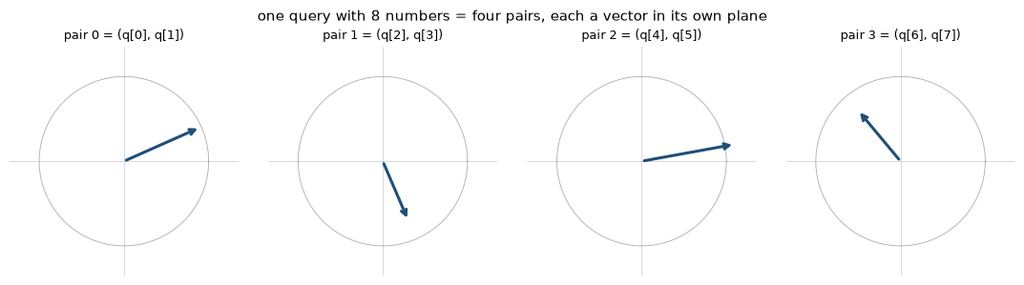

```python
q8 = np.array([0.90, 0.40, 0.30, -0.70, 1.10, 0.20, -0.50, 0.60])
print("the vector:  ", "  ".join(f"{v:+.2f}" for v in q8))
print("read as pairs:", "  ".join(f"[{q8[2*j]:+.2f},{q8[2*j+1]:+.2f}]"
                                  for j in range(4)))

fig, axes = plt.subplots(1, 4, figsize=(11, 3.0))
for j, ax in enumerate(axes):
    circle_ax(ax)
    arrow(ax, q8[2 * j:2 * j + 2], C_BLUE)
    ax.set_title(f"pair {j} = (q[{2*j}], q[{2*j+1}])", fontsize=9)
fig.suptitle("one query with 8 numbers = four pairs, each a vector in its own plane", fontsize=11)
plt.tight_layout(); plt.show()
```

### $j$ sets the rate, $m$ sets the amount

Each pair $j$ gets its own rotation rate $\theta_j = 10000^{-2j/d}$ — pair 0 fast, the last pair slow. A token at sentence position $m$ has every pair turned by $m\,\theta_j$.

Below: the **same word** (same eight numbers out of $W_Q$) placed at positions $m = 0,1,2,3$. Fast pairs fan out; the slow pair barely moves. The fan is the position code.

```
rates: theta_0=1.0000 rad/pos  theta_1=0.1000 rad/pos  theta_2=0.0100 rad/pos  theta_3=0.0010 rad/pos
```

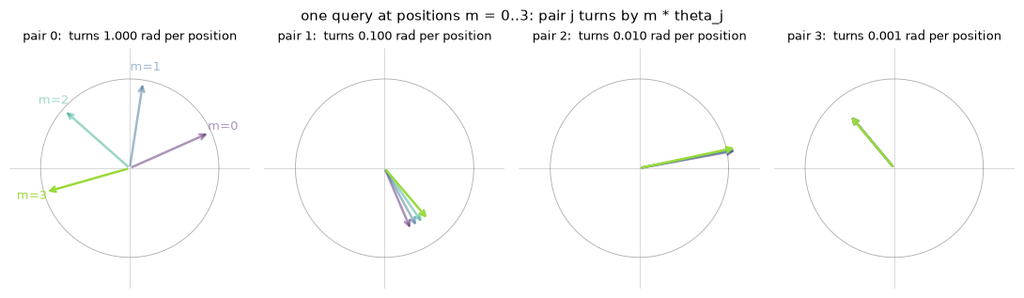

```
pair 0 length at m=0..3: 0.9849 0.9849 0.9849 0.9849  -- the rotation does not change the length
```

```python
theta8 = 10000.0 ** (-2.0 * np.arange(4) / 8)
print("rates:", "  ".join(f"theta_{j}={t:.4f} rad/pos" for j, t in enumerate(theta8)))

fig, axes = plt.subplots(1, 4, figsize=(11, 3.2))
colors_m = plt.cm.viridis(np.linspace(0.05, 0.85, 4))
for j, ax in enumerate(axes):
    circle_ax(ax)
    for m in range(4):
        arrow(ax, rotate(q8[2 * j:2 * j + 2], m * theta8[j]), colors_m[m],
              label=f"m={m}" if j == 0 else None, lw=1.8,
              alpha=0.45 + 0.55 * (m == 3))
    ax.set_title(f"pair {j}:  turns {theta8[j]:.3f} rad per position", fontsize=9)
fig.suptitle("one query at positions m = 0..3: pair j turns by m * theta_j",
             fontsize=11)
plt.tight_layout(); plt.show()

lengths = [np.linalg.norm(rotate(q8[0:2], m * theta8[0])) for m in range(4)]
print("pair 0 length at m=0..3:", " ".join(f"{v:.4f}" for v in lengths),
      " -- the rotation does not change the length")
```

# Part 2 of 4 — What the score depends on

The dot product of two pairs reads exactly three things: both lengths and the **angle between them** — $q\cdot k = r_q r_k \cos(\varphi_k - \varphi_q)$. Each angle *alone* is invisible to it. RoPE hides position in that blind spot: rotating **both** arrows by a shared amount cancels in the difference, and what does not cancel is $ (n - m)\,\theta$ — the offset.

Measured, every pair of positions with the same offset:

```python
k8 = np.array([0.30, 0.90, -0.40, 0.50, 0.70, -0.10, 0.20, 0.80])

def rope8(v, m):
    return np.concatenate([rotate(v[2 * j:2 * j + 2], m * theta8[j])
                           for j in range(4)])

print(f"{'q at m':>7} {'k at n':>7} {'offset':>7} {'score q·k':>12}")
for m, n in [(0, 0), (3, 3), (900, 900), (0, 2), (3, 5), (100, 102), (900, 902)]:
    s = rope8(q8, m) @ rope8(k8, n)
    print(f"{m:>7} {n:>7} {n - m:>7} {s:>12.6f}")
print("-> equal offsets n - m give equal scores, wherever the two tokens are.")
```

```
 q at m  k at n  offset    score q·k
      0       0       0     1.290000
      3       3       0     1.290000
    900     900       0     1.290000
      0       2       2    -0.188503
      3       5       2    -0.188503
    100     102       2    -0.188503
    900     902       2    -0.188503
-> equal offsets n - m give equal scores, wherever the two tokens are.
```